# 5_single_samples

Nick Schultz

3/7/2021

## Single Samples

Questions: 1. what is mean value? 2. is mean value significantly different from current expectation or theory? 3. what is the level of uncertainty associated with our estimate of the mean values?

First, we must establish: 1. are the values normally distributed? 2. are there outliers in the data? 3. if data were collected over a period of time, is there evidence for serial correlation? Non-normality, outliers, and serial correlation can invalidate inferences made by parametric tests, i.e. Student’s t test. (Might need to use non-parametric techniques such as Wilcoxon’s signed-rank test; if serial correlation, need to use time series analysis or mixed effectes model.)

```r
library(ggplot2)
library(readr)

data <- read.csv("example.csv")
data2 <- read_csv("example.csv")
head(data2)
```

```
## # A tibble: 6 x 1
##       y
##   <dbl>
## 1  2.51
## 2  2.56
## 3  2.46
## 4  2.70
## 5  2.57
## 6  2.41
```

```r
names(data)
```

```
## [1] "y"
```

```r
summary(data)
```

```
##        y
##  Min.   :1.904
##  1st Qu.:2.241
##  Median :2.414
##  Mean   :2.419
##  3rd Qu.:2.568
##  Max.   :2.984
```

```r
summary(data2)
```

```
##        y
##  Min.   :1.904
##  1st Qu.:2.241
##  Median :2.414
##  Mean   :2.419
##  3rd Qu.:2.568
##  Max.   :2.984
```

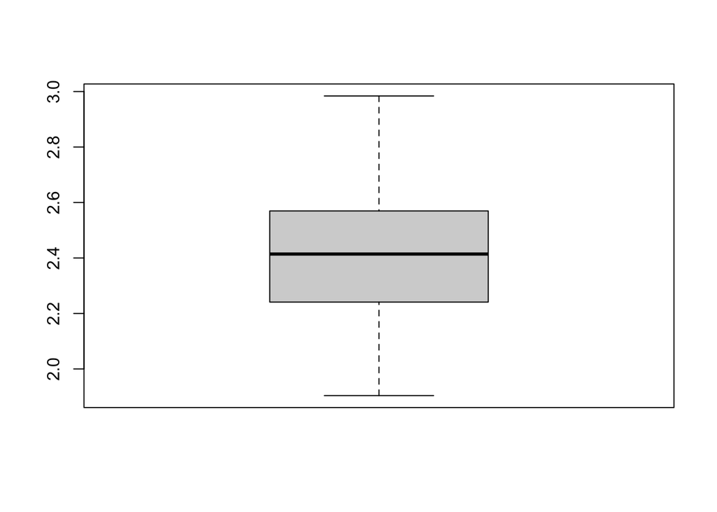

```r
boxplot(data$y)
```

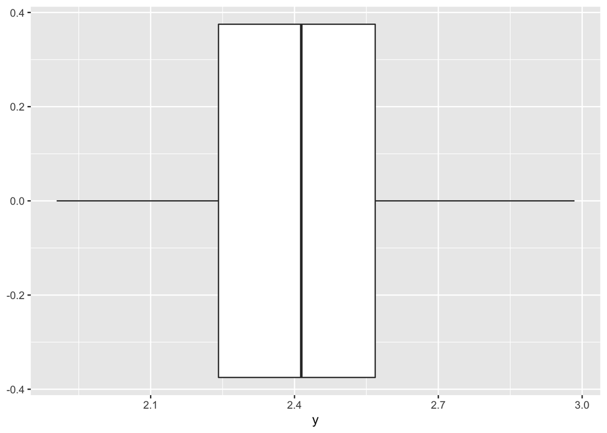

```r
ggplot(data = data2, aes(y)) +
  geom_boxplot()
```

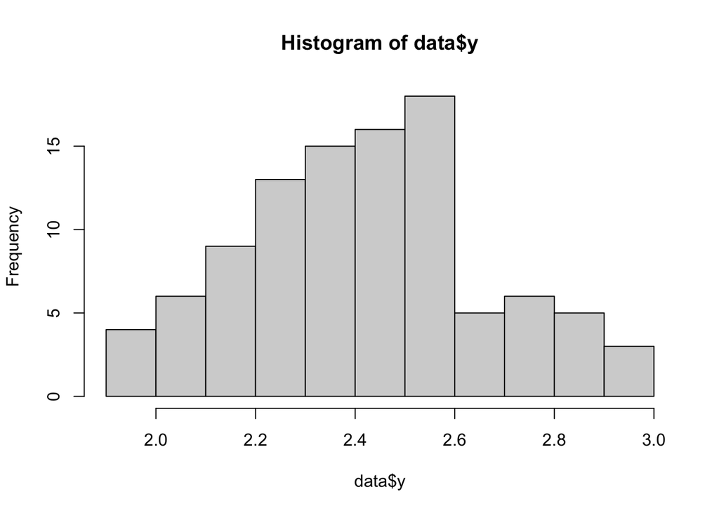

```r
hist(data$y)
```

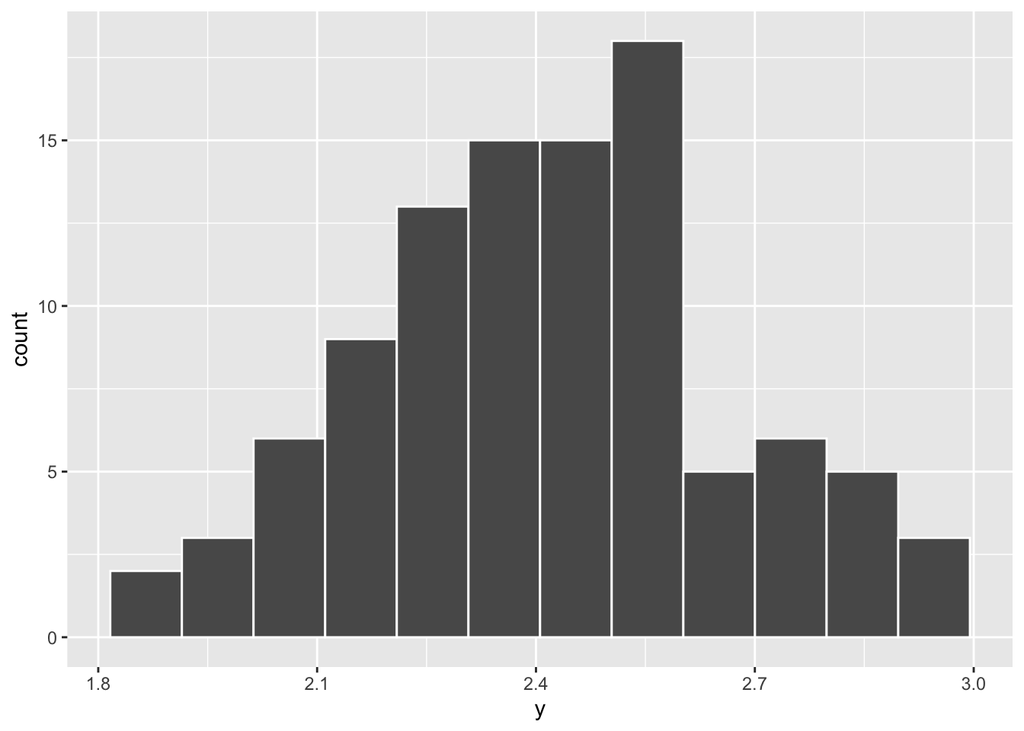

```r
ggplot(data, aes(y)) +
  geom_histogram(bins = 12, color = "white")
```

Calculations using z of the Normal distribution suppose we have heights of 100 people; mean height = 170 cm; sd = 8 cm.

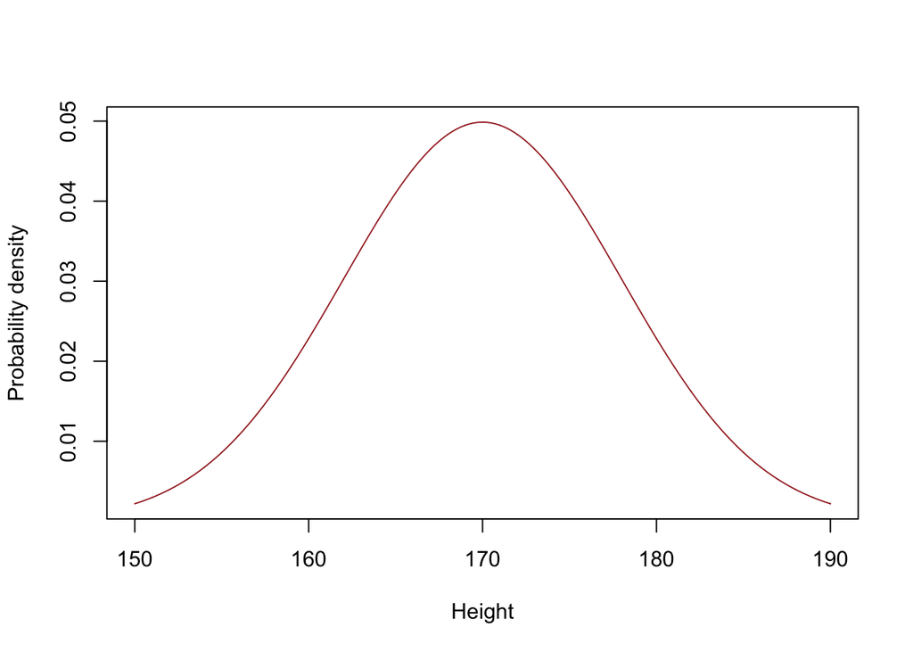

```r
ht <- seq(150, 190, 0.01)

plot(ht, dnorm(x = ht, mean = 170, sd = 8), type = "l", col = "brown",
     ylab = "Probability density", xlab = "Height")
```

We can ask three sorts of questions: 1. shorter than particular height? 2. taller than particular height? 3. between one specified height and another?

Convert height into a value of z, i.e. convert height into a number of standard deviations from the mean.

Question: what is the probability that one person selected at random will be less than 160 cm tall?

```r
z <- (160 - 170) / 8

pnorm(z)
```

```
## [1] 0.1056498
```

What is probabilty that person is taller than 185 cm?

```r
z2 <- (185 - 170) / 8

1 - pnorm(z2)
```

```
## [1] 0.03039636
```

What is probability that person is between 165 cm and 180 cm?

```r
z_1 <- (165 - 170) / 8
z_2 <- (180 - 170) / 8

pnorm(z_2) - pnorm(z_1)
```

```
## [1] 0.6283647
```

Plots for testing normality of samples

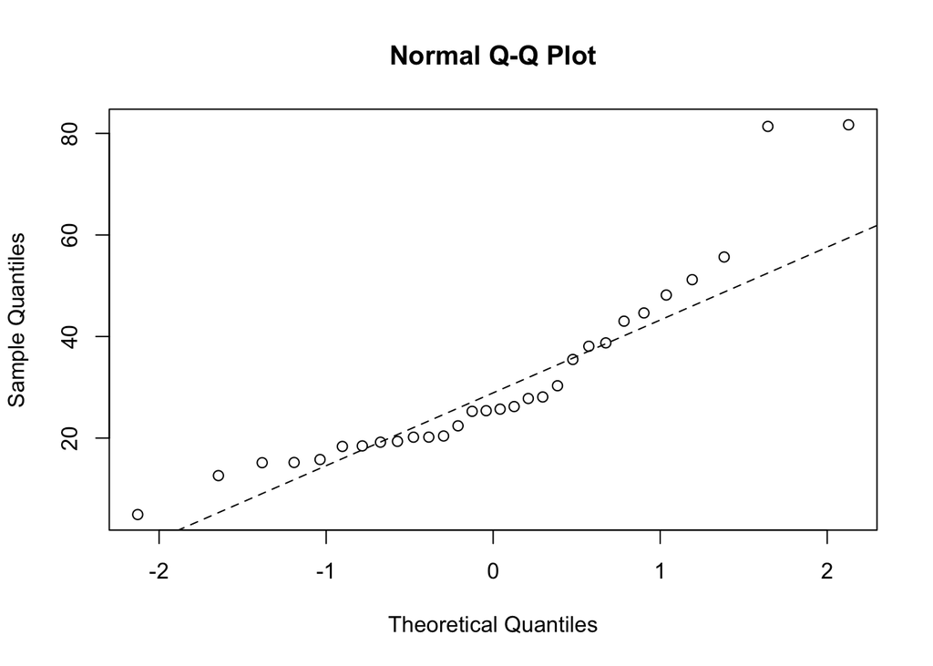

```r
data <- read.csv("skewdata.csv")

qqnorm(data$values)
qqline(data$values, lty = 2)
```

Data with outliers

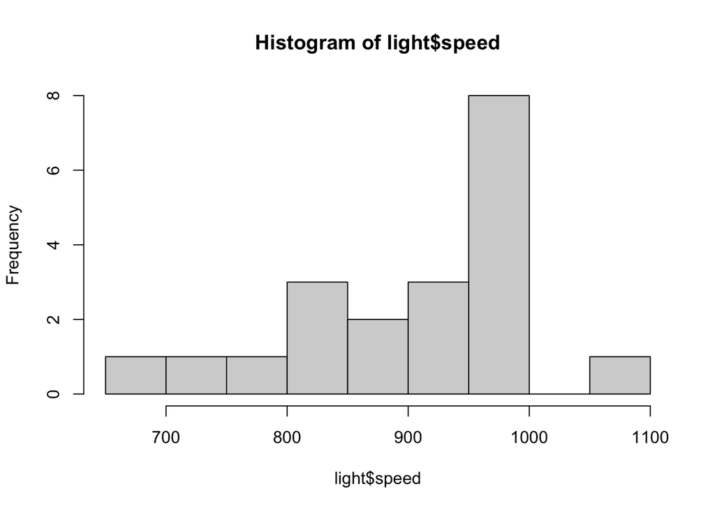

```r
light <- read.csv("light.csv")

hist(light$speed)
```

```r
summary(light$speed)
```

```
##    Min. 1st Qu.  Median    Mean 3rd Qu.    Max.
##     650     850     940     909     980    1070
```

Outlier rule of thumb: value 1.5 times the interquartile range

```r
850 - ((980 - 850) * 1.5)
```

```
## [1] 655
```

```r
980 + ((980 - 850) * 1.5)
```

```
## [1] 1175
```

Inference in one-sample case

```r
wilcox.test(x = light$speed, mu = 990)
```

```
##
##  Wilcoxon signed rank test with continuity correction
##
## data:  light$speed
## V = 22.5, p-value = 0.00213
## alternative hypothesis: true location is not equal to 990
```

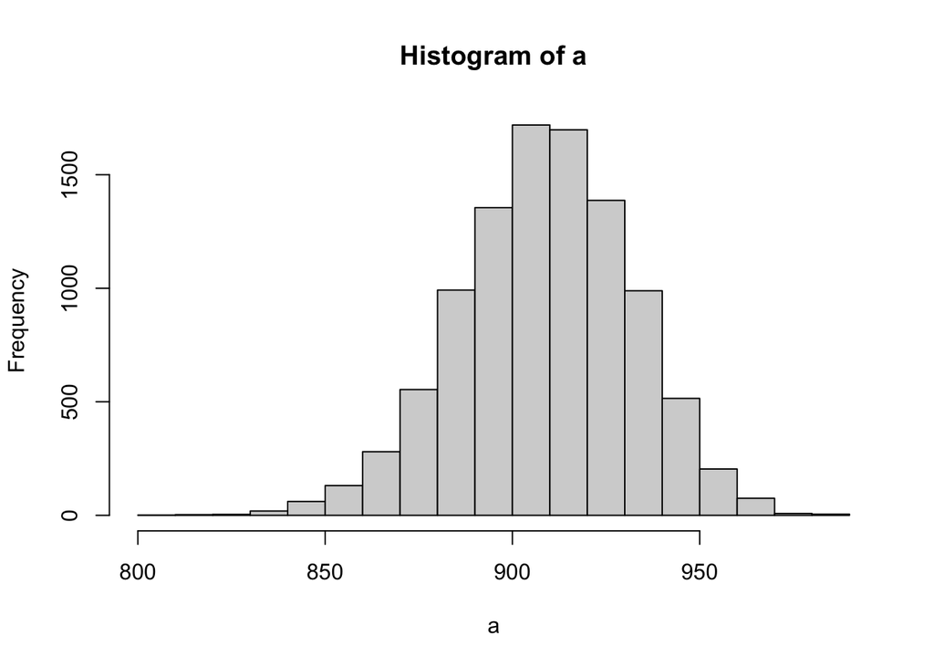

```r
a <- numeric(10000)
for (i in 1:10000) a[i] <- mean(sample(x = light$speed, replace = TRUE))
hist(a)
```

```r
max(a)
```

```
## [1] 986.5
```

```r
mean(a)
```

```
## [1] 908.9859
```

```r
sd(a)
```

```
## [1] 22.94011
```

Skew

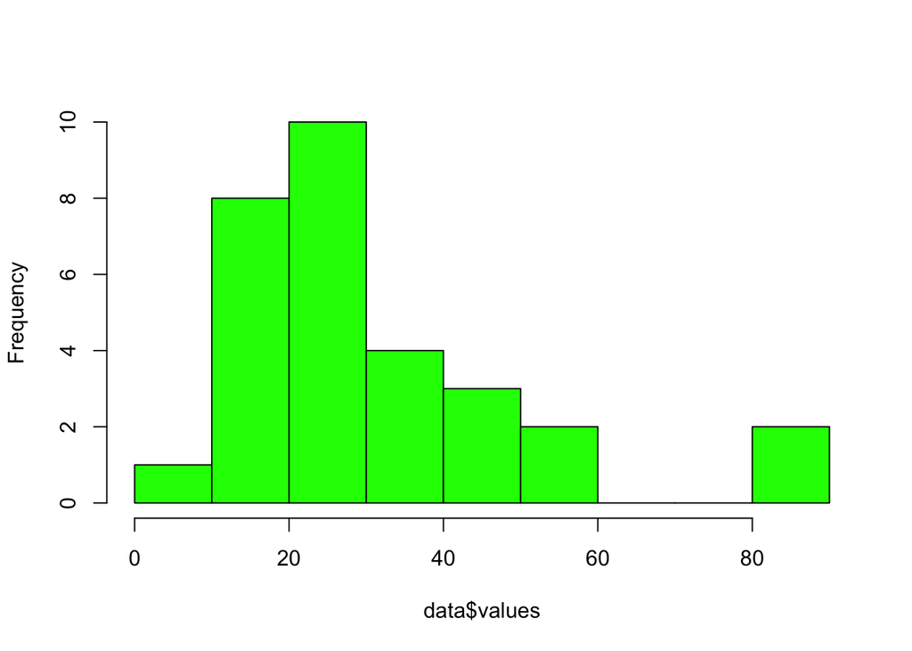

```r
skew <- function(x) {
  m3 <- sum((x - mean(x))^3)/ length(x)
  s3 <- sqrt(var(x))^3
  m3/s3
}

hist(data$values, main = "", col = "green")
```

```r
skew(data$values)
```

```
## [1] 1.318905
```

```r
t_test <- skew(data$values)/sqrt(6/length(data$values))

1 - pt(t_test, length(data$values) - 2)
```

```
## [1] 0.003183872
```

```r
skew(sqrt(data$values))/sqrt(6/length(data$values))
```

```
## [1] 1.474851
```

```r
skew(log(data$values))/sqrt(6/length(data$values))
```

```
## [1] -0.6600605
```

Kurtosis

```r
kurtosis <- function(x){
  m4 <- sum((x - mean(x))^4)/length(x)
  s4 <- var(x)^2
  m4/s4 - 3
}

kurtosis(data$values)
```

```
## [1] 1.297751
```

```r
kurtosis(data$values)/sqrt(24/length(data$values))
```

```
## [1] 1.45093
```